# Get to know me!

Anzar Alvi

2026-01-31

# Anzar Alvi

## Bio

My name is Anzar! I am a 4th-year Computational Biology Specialist and Computer Science Major. I work with Dr. Phedias Diamandis and Dr. Kieran Campbell and am fascinated by the use of AI technologies for improving patient care. I intend to do a masters in Bioinformatics or a related field to continue pursuing my interests!

## Bachelors Degree

### Table of courses

**Table 1. Record of all undergraduate courses**

```r
paged_table(courses)
```

| Course_Department | Course_Code | Year | course_type |
| --- | --- | --- | --- |
| BCB | 330 | 4 | HBSc Requirement |
| BCB | 410 | 4 | HBSc Requirement |
| CSC | 209 | 3 | HBSc Requirement |
| RLG | 376 | 3 | Elective |
| BCH | 311 | 2 | HBSc Requirement |
| RLG | 234 | 2 | Elective |
| MAT | 135 | 1 | HBSc Requirement |
| POL | 107 | 1 | Elective |

### Plot of courses

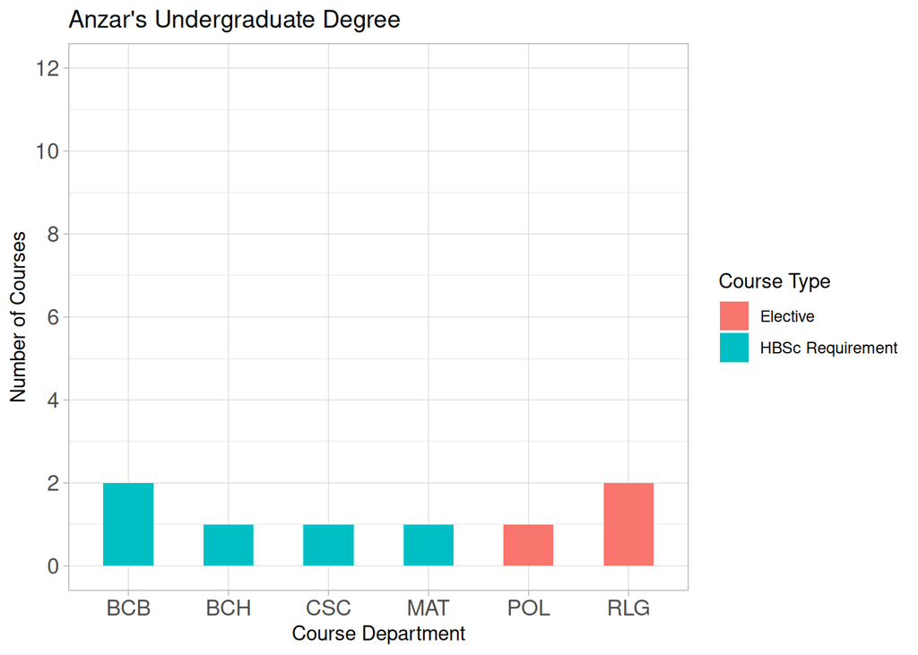

**Anzar’s Undergraduate Degree** Figure 1 summary of undergraduate courses barplot of the number of courses taken throughout the undergraduate degree. Colors represent the catagory of each course as part of the undergraduate course requirements.

```r
## organize the data for plotting
courses_counts <- courses %>%
  group_by(Course_Department, course_type) %>%
  count()

# plot
ggplot(data=courses_counts, aes(x=Course_Department, y=n, fill=course_type)) +
  geom_bar(stat="identity", width=0.5) +
  labs(y="Number of Courses", x="Course Department", fill="Course Type") +
  theme_light() +
  scale_y_continuous(limits = c(0, 12), breaks = seq(0, 12, by = 2))+
  ggtitle("Anzar's Undergraduate Degree")+
  theme(axis.text.y=element_text(size=12),
        axis.text.x=element_text(size=12))
```

## Hobbies

### Description

I have many hobbies such as: playing guitar, reading, and going to the gym. I have outlined how many hours a week I spend on each hobby.

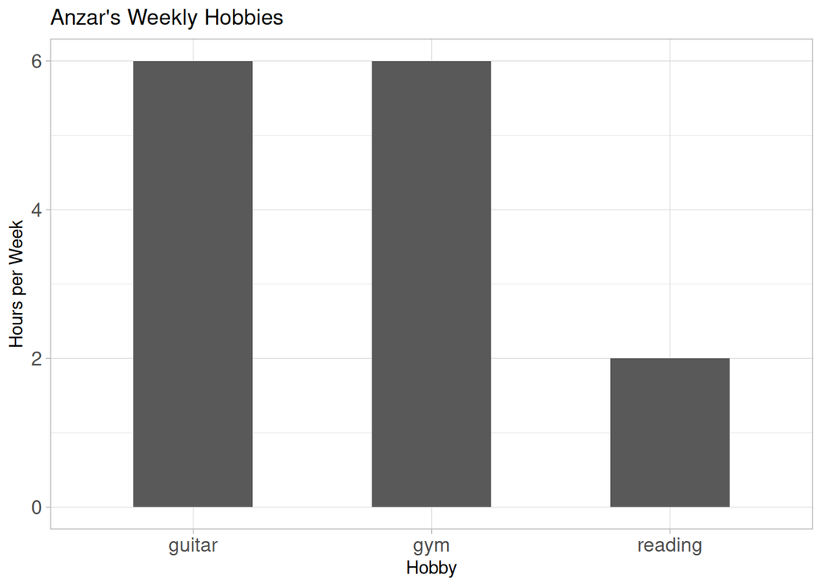

**Anzar’s Hobbies** Figure 2 barplot of the number of hours spent a week on each hobby.

```r
# plot
ggplot(data=hobbies, aes(x=hobby, y=hours_per_week)) +
  geom_bar(stat="identity", width=0.5) +
  labs(y="Hours per Week", x="Hobby") +
  theme_light() +
  ggtitle("Anzar's Weekly Hobbies")+
  theme(axis.text.y=element_text(size=12),
        axis.text.x=element_text(size=12))
```

### Favorite Hobby

Currently, my favorite hobby is playing the guitar!

## Travelling!

I’m always looking to travel and explore the world. I went to Australia recently for the first time. See a picture below!

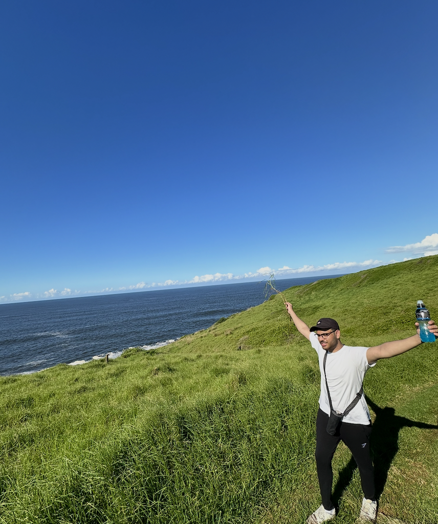

Hiking in Kiama!

## Questions to answer

1.What is your bachelors degree?

2.Which courses have you taken and in which departments?

3.What are your hobbies?

4.How many hours a week do you spend on each hobby?

5.What is your favorite hobby?

6.Add a custom section of your choosing!